# Data 607 HW 12

Alice Friedman

11/24/2018

# Introduction

The purpose of this assignment is to migrate data from a relational database to a NoSQL relational database. We will demonstrate how to move from a dataframe to a graph database using igraph and then RNeo4J.

# Load the Flights Database

```r
library(nycflights13)
library(dplyr)
```

```r
glimpse(flights)
```

```
## Observations: 336,776
## Variables: 19
## $ year           <int> 2013, 2013, 2013, 2013, 2013, 2013, 2013, 2013,...
## $ month          <int> 1, 1, 1, 1, 1, 1, 1, 1, 1, 1, 1, 1, 1, 1, 1, 1,...
## $ day            <int> 1, 1, 1, 1, 1, 1, 1, 1, 1, 1, 1, 1, 1, 1, 1, 1,...
## $ dep_time       <int> 517, 533, 542, 544, 554, 554, 555, 557, 557, 55...
## $ sched_dep_time <int> 515, 529, 540, 545, 600, 558, 600, 600, 600, 60...
## $ dep_delay      <dbl> 2, 4, 2, -1, -6, -4, -5, -3, -3, -2, -2, -2, -2...
## $ arr_time       <int> 830, 850, 923, 1004, 812, 740, 913, 709, 838, 7...
## $ sched_arr_time <int> 819, 830, 850, 1022, 837, 728, 854, 723, 846, 7...
## $ arr_delay      <dbl> 11, 20, 33, -18, -25, 12, 19, -14, -8, 8, -2, -...
## $ carrier        <chr> "UA", "UA", "AA", "B6", "DL", "UA", "B6", "EV",...
## $ flight         <int> 1545, 1714, 1141, 725, 461, 1696, 507, 5708, 79...
## $ tailnum        <chr> "N14228", "N24211", "N619AA", "N804JB", "N668DN...
## $ origin         <chr> "EWR", "LGA", "JFK", "JFK", "LGA", "EWR", "EWR"...
## $ dest           <chr> "IAH", "IAH", "MIA", "BQN", "ATL", "ORD", "FLL"...
## $ air_time       <dbl> 227, 227, 160, 183, 116, 150, 158, 53, 140, 138...
## $ distance       <dbl> 1400, 1416, 1089, 1576, 762, 719, 1065, 229, 94...
## $ hour           <dbl> 5, 5, 5, 5, 6, 5, 6, 6, 6, 6, 6, 6, 6, 6, 6, 5,...
## $ minute         <dbl> 15, 29, 40, 45, 0, 58, 0, 0, 0, 0, 0, 0, 0, 0, ...
## $ time_hour      <dttm> 2013-01-01 05:00:00, 2013-01-01 05:00:00, 2013...
```

# Normalize the flights database

We will create a small relational database using a subset of the flights data.

```r
remove(flights)
library(nycflights13)
library(dplyr)
library(tidyr)
```

```r
glimpse(flights)
```

```
## Observations: 336,776
## Variables: 19
## $ year           <int> 2013, 2013, 2013, 2013, 2013, 2013, 2013, 2013,...
## $ month          <int> 1, 1, 1, 1, 1, 1, 1, 1, 1, 1, 1, 1, 1, 1, 1, 1,...
## $ day            <int> 1, 1, 1, 1, 1, 1, 1, 1, 1, 1, 1, 1, 1, 1, 1, 1,...
## $ dep_time       <int> 517, 533, 542, 544, 554, 554, 555, 557, 557, 55...
## $ sched_dep_time <int> 515, 529, 540, 545, 600, 558, 600, 600, 600, 60...
## $ dep_delay      <dbl> 2, 4, 2, -1, -6, -4, -5, -3, -3, -2, -2, -2, -2...
## $ arr_time       <int> 830, 850, 923, 1004, 812, 740, 913, 709, 838, 7...
## $ sched_arr_time <int> 819, 830, 850, 1022, 837, 728, 854, 723, 846, 7...
## $ arr_delay      <dbl> 11, 20, 33, -18, -25, 12, 19, -14, -8, 8, -2, -...
## $ carrier        <chr> "UA", "UA", "AA", "B6", "DL", "UA", "B6", "EV",...
## $ flight         <int> 1545, 1714, 1141, 725, 461, 1696, 507, 5708, 79...
## $ tailnum        <chr> "N14228", "N24211", "N619AA", "N804JB", "N668DN...
## $ origin         <chr> "EWR", "LGA", "JFK", "JFK", "LGA", "EWR", "EWR"...
## $ dest           <chr> "IAH", "IAH", "MIA", "BQN", "ATL", "ORD", "FLL"...
## $ air_time       <dbl> 227, 227, 160, 183, 116, 150, 158, 53, 140, 138...
## $ distance       <dbl> 1400, 1416, 1089, 1576, 762, 719, 1065, 229, 94...
## $ hour           <dbl> 5, 5, 5, 5, 6, 5, 6, 6, 6, 6, 6, 6, 6, 6, 6, 5,...
## $ minute         <dbl> 15, 29, 40, 45, 0, 58, 0, 0, 0, 0, 0, 0, 0, 0, ...
## $ time_hour      <dttm> 2013-01-01 05:00:00, 2013-01-01 05:00:00, 2013...
```

```r
flights_raw <- flights

airports <- flights_raw %>%
  select(origin, dest) %>%
  gather(value = "airportCode") %>%
  select(airportCode) %>%
  distinct() %>%
  arrange(airportCode) %>%
  glimpse()
```

```
## Observations: 107
## Variables: 1
## $ airportCode <chr> "ABQ", "ACK", "ALB", "ANC", "ATL", "AUS", "AVL", "...
```

```r
flights <- flights_raw %>%
  select(origin, dest, flight, carrier) %>%
  group_by(origin, dest, flight, carrier) %>%
  summarize(count = n()) %>%
  arrange(desc(count)) %>%
  glimpse()
```

```
## Observations: 12,075
## Variables: 5
## $ origin  <chr> "EWR", "EWR", "JFK", "JFK", "JFK", "JFK", "JFK", "JFK"...
## $ dest    <chr> "HNL", "LAX", "BUR", "CLT", "IAD", "LAS", "LAX", "LAX"...
## $ flight  <int> 15, 119, 359, 219, 5712, 251, 181, 407, 413, 1783, 215...
## $ carrier <chr> "UA", "AA", "B6", "B6", "EV", "VX", "AA", "VX", "VX", ...
## $ count   <int> 365, 365, 365, 365, 365, 365, 365, 365, 365, 365, 365,...
```

# Visualize the data as a graph using igraph

Now we have two tables, which could be linked using the airport code as a primary/foreign key in a relational database. (We don’t have the data, but one could imagine including more properties in the airports table, for example, full name, city, number of terminals, etc.)

We can visualize the airports as nodes and scheduled flights as relationships between them.

```r
library(igraph)
```

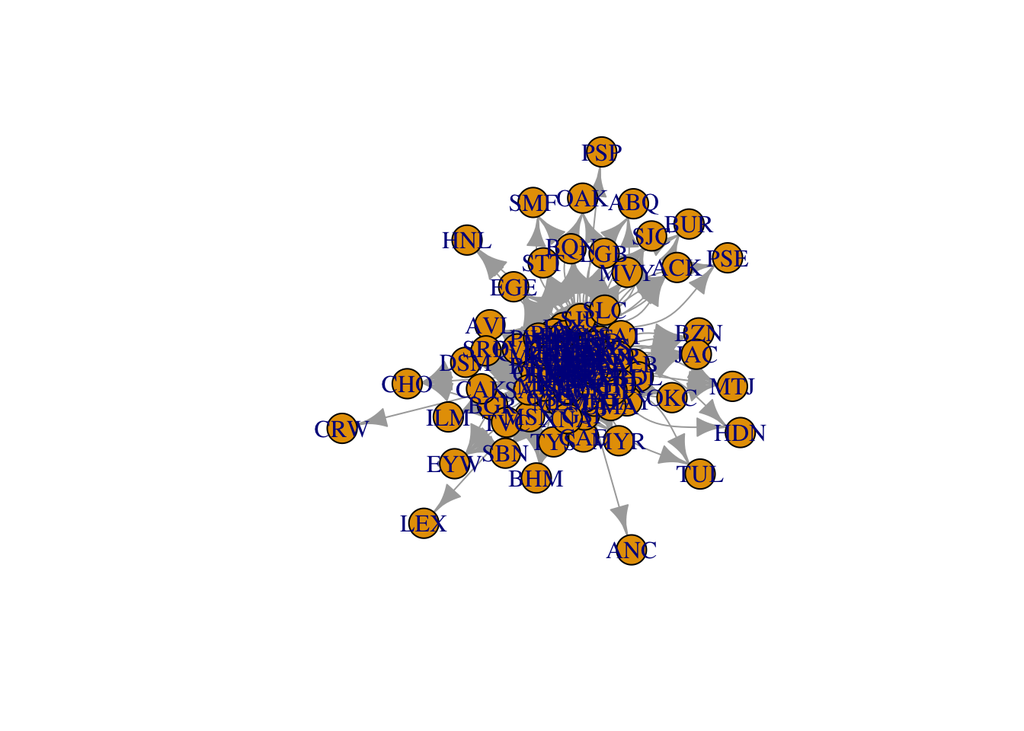

```r
g <- graph_from_data_frame(flights, directed=TRUE, vertices=airports)
plot.igraph(g)
```

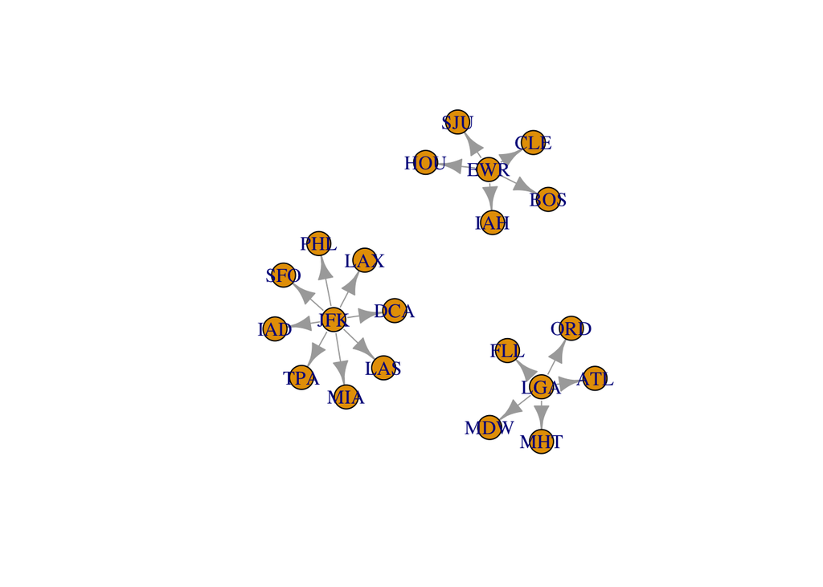

```r
daily_flights <- flights %>% filter(count >=365)
eids <- daily_flights$flight
plot(subgraph.edges(g, eids, delete.vertices = TRUE), width = 10)
```

# Connect to Neo4J

## Get Started

RNeo4J is not yet available on CRAN. Install from the developer’s Git Hub site using devtools:

```
install.packages("devtools")
devtools::install_github("nicolewhite/RNeo4j")
```

Once installed, load using the `library` function, as you would with any other package.

```r
library(RNeo4j)
```

This connection is through an Amazon Web Server virtual Ubuntu machine. This was done to avoid configuration issues using a Mac, and to ensure reproducibility. For a fuller explanation on how to configure an Amazon Web Serives virtual machine, see https://timhagmann.com/html/e63/hw2-hagmann-tim.html#appendix:_neo4j_setup

```r
graph <- startGraph(
  #This links to my virtual machine
  url = "http://ec2-18-212-155-38.compute-1.amazonaws.com:7474/db/data/",
  username = "neo4j",
  password = "neopw",
  #this option will give you back R in case you write a bad query by timing out after 2 seconds
  opts = list(timeout=2))
```

# Build the NoSQL Database in Neo4J

Once again, we will simplify our analysis by using only those flights which occur at least 365 times (most likley daily flights, which we have stored as `daily_flights`).

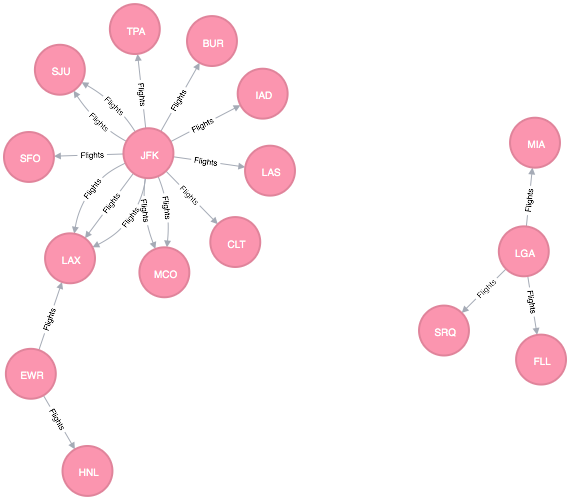

Neo4J Browser Results

```r
clear(graph, input = F)

addConstraint(graph, "airports", "airportCode")
addConstraint(graph, "flights", "flight")

for(i in 1:length(daily_flights$flight)){
  origin = getOrCreateNode(graph, "airports", airportCode = daily_flights[i,]$origin)
  dest = getOrCreateNode(graph, "airports", airportCode = daily_flights[i,]$dest)
  createRel(origin, "Flights", dest)
}
```

# Conclusion

A relational database is very powerful, but it can be tricky to maintain joins across multiple types of relationships. For a very simple database, such as the one we have here, probably a relational database is easier to work with; however, we can imagine adding more kinds of data, for example more informaiton about the airports, or people who visit them, or carriers, where a relational database would quickly become overwhelmed–or at least overwhelming. For a data structure that may change frequently, or be heavily based on different types of relationships, a NoSQL database may be preferred.

# References

A good explanation of how to configure Neo4J to run on an Amazon Web Services Virtual Machine can be found here: https://timhagmann.com/html/e63/hw2-hagmann-tim.html#appendix:_neo4j_setup

Code adapted and inspiration from data scientist Nicole White at [her blog](https://nicolewhite.github.io/2014/05/30/demo-of-rneo4j-part1.html).